# Cartomob Mapathon 2020

Tous (im)mobiles, tous cartographes ?

Christophe Regouby

07/10/2020

# Introduction

Le jeu de données proposé pour le **mapathon 2020 de Cartomob** regroupe un jeu de donnée des flux de transport aéronautique en France métropolitaine, échantillonné sur 5 années clef entre 1999 et 2019, et une série temporelle de donnée de comptage de ces flux aéronautiques par ville et par mois entre 2010 et 2020. Nous avons choisi de nous concentrer sur l’année 2019, car récente, et présente dans les deux jeux de donnée.

# Une France Jacobine

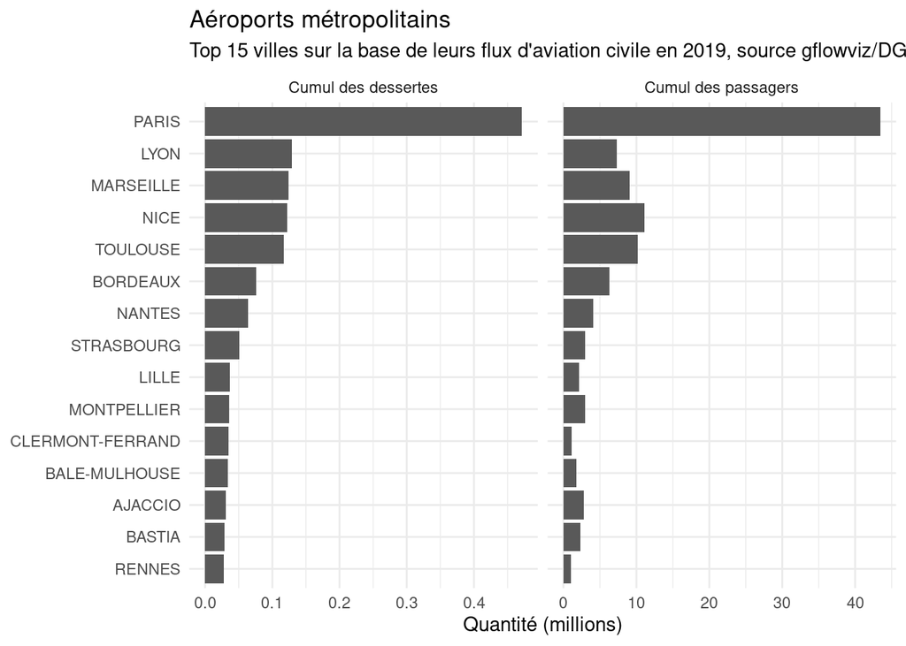

Au delà de la suprématie des aéroports de Paris, il semble intéressant alors de regrouper les flux des 4 premiers aéroports régionaux, séparés du reste des flux métropolitains:

# Des flux très hétérogènes

On prend l’hypothèse que les flux de passagers sont symétriques, i.e. que les billets de passagers sont très majoritairement des aller-retours, pour cartographier les flux sur des lignes inter-villes:

## Paris

Les flux des seuls aéroports de **Paris** *(utiliser la souris pour zoomer)*

[interactive chart not shown]

On réalise que Paris ne dessert en étoile que des villes qui lui sont plus méridionales : on imagine facilement que le trafic vers le nord est capturé par les trains à grande vitesse et par les liaisons aériennes internationales des capitales proches (Londres, Bruxelles, Amsterdam, …).

## Lyon - Marseille - Nice - Toulouse

Ou les **4 fantastiques** :

[interactive chart not shown]

Le quatuor d’aéroports régionaux Lyon-Marseille-Nice-Toulouse qui cumulent ensemble un nombre de mouvements d’avion équivalent à Paris, dessinent une carte des flux majoritairement orientée Nord-Ouest . On s’étonne ici de la forme globale très différente de celle de Paris, car aucune typologie d’étoile n’émerge.

## Les liaisons entre les autres aéroports

[interactive chart not shown]

Pour les autres liaisons inter-régionales,une fois encore l’orientation Ouest-Nord-Ouest prédomine. Au delà de la forme générale reproduisant les frontières de l’hexagone, on constate que l’extrême Sud-Ouest est peu desservi. Les liaisons orientées Nord-Est sont accaparées par le train à grande vitesse, ou des lignes internationales vers les pays voisins (Suisse, Allemagne, Belgique, Hollande, Angleterre…)